# Clase semana 2 - Análisis cuantitativo para la toma de decisiones

Fernando Cortés Tejada

31/03/2023

## Agenda

1. Distribuciones multivariadas  
   1.1. Vector aleatorio  
   1.2. Distribuciones conjuntas, marginales y condicionales  
   1.3. Valor esperado y matrices de varianza y covarianza  
   1.4. Correlación

## Distribuciones Multivariadas

**Ejemplo**

Sea $X =$ Nivel de producción semanal en litros de dos marcas A y B de un solvente industrial y $Y =$ Nivel de producción semanal en litros de la marca A del solvente. Si $(X, Y)$ es un vector aleatorio con la siguiente función de densidad conjunta:

$$f_{X Y}(x,y) = \left\{ \begin{array}{cl}
C y^2 e^{-x} &, \quad \mbox{si} \ 0 < y < x < \infty \\
0 &, \quad\mbox{en caso contrario}
\end{array}
\right.$$

1. Halle la constante normalizadora $C$
2. Halle la probabilidad de que en una semana la producción del solvente $A$ supere el 75% de toda la producción.
3. ¿Son $X$ e $Y$ v.a’s independientes?

*Sugerencia*: utilizar

$$\Gamma(z) = \int_0^{\infty} t^{z-1}
e^{-t}dt.$$

**Solución**

**[a]** Para hallar $C$, tomemos en cuenta que

$$\int_{-\infty}^{\infty}
\int_{-\infty}^{\infty} f_{XY}(x,y)dxdy = 1$$

entonces

$$\begin{aligned}
\int_{-\infty}^{\infty} \int_{-\infty}^{\infty} f_{XY}(x,y)dxdy &= C
\int_{0}^{\infty} \left(\int_{0}^{x} y^2 e^{-x} dy\right)dx \\
&= C \int_{0}^{\infty} e^{-x} \left(\int_{0}^{x} y^2 dy\right)dx
\\
&= C \int_{0}^{\infty} \frac{x^3}{3} e^{-x}dx \\
&= \frac{C}{3} \Gamma(4) \\
&= 2 C = 1 \\
\Rightarrow C &= \frac{1}{2}
\end{aligned}$$

Por tanto, $C = \frac{1}{2}$. Geométricamente, lo de arriba nos dice que el volumen bajo la función $f_{X Y}$ sobre su rango es 1. El rango utilizado lo podemos ver en la siguiente imagen:

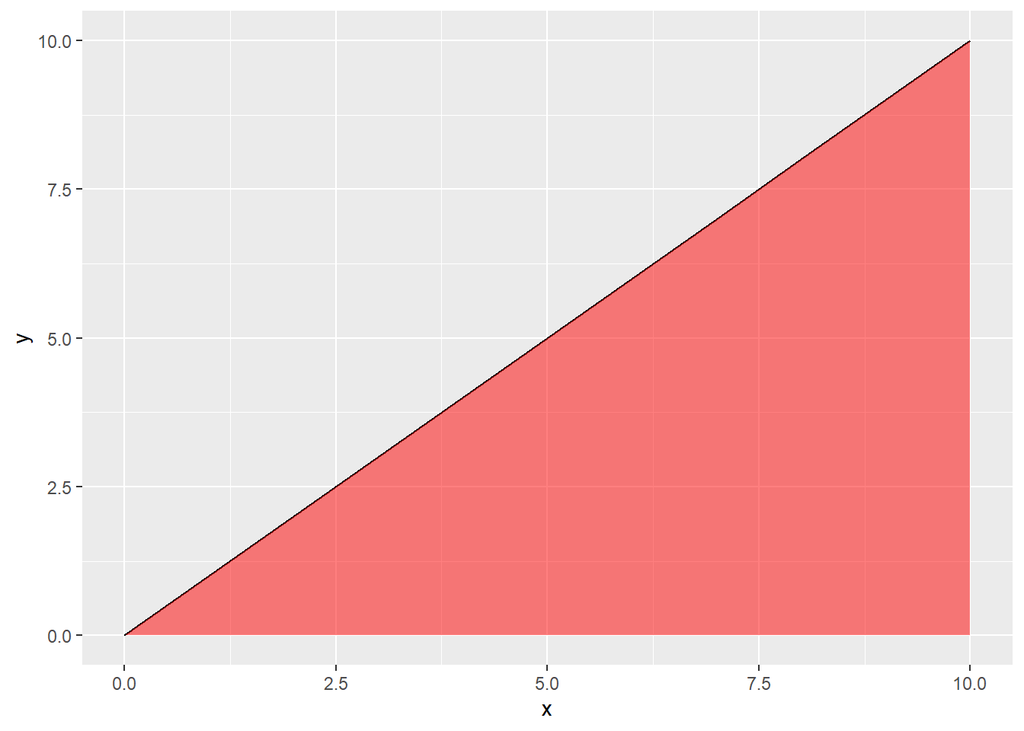

Es recomendable graficar la región de integración, pues ella nos permitirá establecer fácilmente los límites de integración.

**[b]** Acá nos piden $P(Y > 0.75 X)$. Esto quiere decir que, adicionalmente a la restricción de $0 \lt y \lt x \lt \infty$, tenemos que agregarle la de $y > 0.75x$. La gráfica de esta región (a la que llamaremos $A$) es

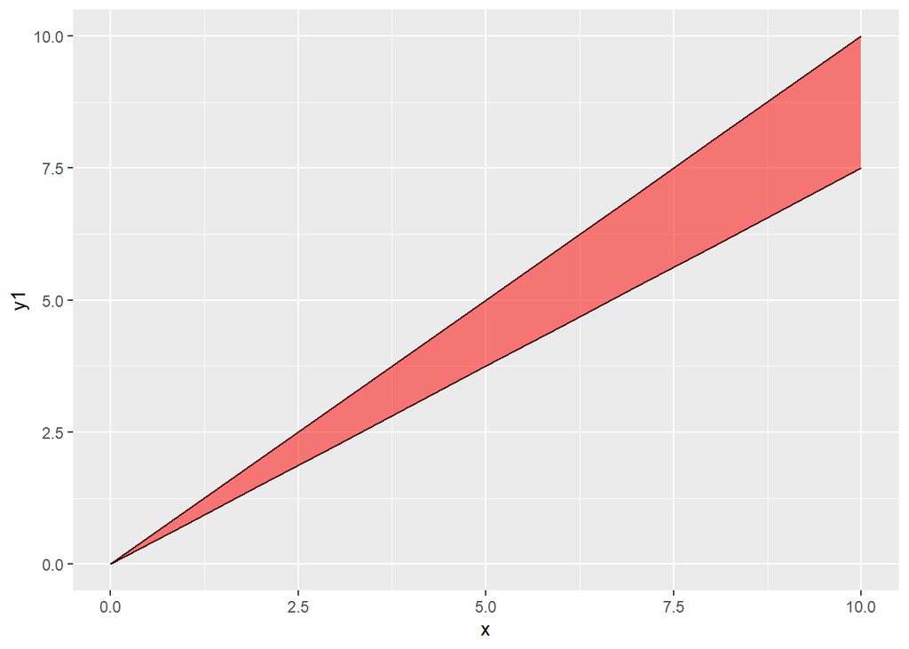

y por tanto, tomando primero un diferencial de $y$ se tiene que

$$\begin{aligned}
P(Y > 0.75 X) &= \int \int_A f_{X Y}(x,y) dx dy \\
&= \int_{0}^{\infty} \frac{e^{-x}}{2}\left(\int_{0.75x}^x y^2
dy\right) dx \\
&= \int_{0}^{\infty} \frac{e^{-x}}{2} \left(\frac{x^3}{3} -
\frac{9x^3}{64}\right)dx \\
&= \frac{37}{384} \int_{0}^{\infty} x^3 e^{-x} dx \\
&= \frac{37}{384} \Gamma(4) = 0.578125
\end{aligned}$$

Por lo que la probabilidad de que el solvente A supere el 75% de toda la producción es 57.8%.

**[c]** Para saber si $X$ y $Y$ son independientes, debemos hallar las distribuciones marginales de cada una. Estas vienen dadas por

$$\begin{aligned}
f_{X}(x) &= \int_0^{x} \frac{1}{2} y^2 e^{-x} dy \\
&= \frac{x^3}{6} e^{-x} , \quad\quad \forall x > 0,
\end{aligned}$$

y

$$\begin{aligned}
f_{Y}(y) &= \int_{y}^{\infty} \frac{1}{2} y^2 e^{-x} dx \\
&= \frac{1}{2} y^2 e^{-y}, \quad\quad \forall y > 0.
\end{aligned}$$

Entonces, podemos tomar un valor cualquiera, como $(x,y) = (2,1)$ por ejemplo, lo que nos da para la distribución conjunta

$$f_{X Y}(2,1) = \frac{1}{2}(1)^2e^{-2} = \frac{1}{2}e^{-2}$$

y para la multiplicación de marginales

$$f_{X}(2) f_{Y}(1) = \frac{2^3}{6}e^{-2} \times \frac{1}{2}(1)^2e^{-1} =
\frac{2}{3}e^{-3},$$

por lo tanto $X$ y $Y$ no son variables aleatorias independientes.

## Valor esperado y matrices de varianza y covarianza

Si transformamos un vector aleatorio ${\bf X}$ en una variable aleatoria $g({\bf X})$, a través de una función $g: {\mathbb R}^k \to {\mathbb R}$, se define el valor esperado de la variable aleatoria $g({\bf X})$ mediante

$$E(g({\bf X}))= \left\{ \begin{array}{cl}
\sum_{{\bf x}} g({\bf x}) P_{X_1 X_2 \ldots X_k}({\bf x})
\\
\int_{-\infty}^{\infty} \ldots \int_{-\infty }^{\infty} g({\bf
x})f_{X_1 X_2 \ldots X_k}({\bf x}) dx_1 dx_2 \ldots dx_k
\end{array}
\right.$$

dependiendo, respectivamente si ${\bf X}$ es un vector aleatorio discreto o continuo.

Esta noción de valor esperado, puede también extenderse a funciones que toman valores en ${\mathbb R}^k$ e incluso matrices, dando pie a dos de las más distintivas características de un vector aleatorio (que ahora escribiremos como un vector columna): su vector de medias y su matriz de varianzas-covarianzas. Ellas están definidas por

$$\boldsymbol{\mu} = E({\bf X}) = \left[\begin{array}{c} \mu_1 \\ \mu_2 \\
... \\ \mu_k \end{array} \right] = [\mu_1, \mu_2, \ldots, \mu_k]^{\top}$$

y

$${\boldsymbol \Sigma} = E\left(({\bf X} - \boldsymbol{\mu})({\bf X} -
\boldsymbol{\mu})^{\top}\right) =
\left[\begin{array}{cccc}
\sigma_{1}^2 & \sigma_{12} & \ldots & \sigma_{1k}\\
\sigma_{12} & \sigma_{2}^2 & \ldots & \sigma_{2k}\\
\vdots & \vdots & \ddots & \vdots\\
\sigma_{1k} & \sigma_{2k} & \ldots & \sigma_{k}^2 \\
\end{array} \right],$$

respectivamente, donde $\mu_i = E(X_i)$, la diagonal de ${\boldsymbol \Sigma}$ contiene a las varianzas $\sigma_i^2 = V(X_i)$ de las variables aleatorias componentes y las entradas $(i,j)$ no diagonales denotan a la covarianza entre la variable $X_i$ y $X_j$.

La covarianza $\sigma_{ij}$, que también acostumbraremos denotarla por $Cov(X_i,X_j)$, es una medida de asociación lineal entre estas variables aleatorias componentes y se define por

$$\sigma_{ij} = E((X_i - \mu_i)(X_j - \mu_j)) = E(X_i X_j) - \mu_i \mu_j$$

## Correlación

Una medida similar a la covarianza es la correlación de Pearson, la cual tiene la ventaja de ser adimensional y acotada. Ella, que la denotaremos por $\rho_{ij}$ o $Cor(X_i, X_j)$, se define por

$$\rho_{ij} = \frac{\sigma_{ij}}{\sigma_i \sigma_j}$$

y tiene las siguientes propiedades importantes:

**Proposición**

- Si $X_i$ y $X_j$ son variables independientes, entonces $\rho_{ij} = 0$.
- $|\rho_{ij}| \leq 1$.
- $| \rho_{ij}| = 1 \Leftrightarrow P(X_j = a + b X_i) = 1$, donde $a = \mu_j - b \mu_i \ \ \ \mbox{y} \ \ \ b = \frac{\sigma_{ij}}{\sigma_i^2}$.

las cuales nos dicen que mientras más cercana este la correlación a 1 (o -1), más lineal y directamente (inversamente) estarán relacionadas las variables $X_i$ y $X_j$.

Al igual que la matriz de varianza-covarianza podemos también definir la matriz de correlaciones de ${\bf X}$ mediante

$$Cor({\bf X}) =
\left[\begin{array}{cccc}
1 & \rho_{12} & \ldots & \rho_{1k}\\
\rho_{12} & 1 & \ldots & \rho_{2k}\\
\cdots & \cdots & \ddots & \cdots\\
\rho_{1k} & \rho_{2k} & \ldots & 1 \\
\end{array} \right].$$

La proposición siguiente nos indica como calcular el vector de medias y la matriz de varianzas-covarianzas de cualquier transformación multilineal de un vector aleatorio.

**Proposición**

Sea ${\bf X}$ un vector aleatorio (columna) $k$-dimensional con vector de medias $\boldsymbol{\mu}$ y matriz de varianzas-covarianzas $\boldsymbol{\Sigma}$, ${\bf A}$ una matriz $m \times k$ de constantes y ${\bf b}$ un vector $m \times 1$ no aleatorio. Si definimos el vector aleatorio $m-$dimensional ${\bf Y}$, mediante la transformación ${\bf Y} = {\bf A} {\bf X} + {\bf b}$, entonces el vector de medias y la matriz de varianzas-covarianzas de ${\bf Y}$ vienen dadas respectivamente por $\boldsymbol{\mu}_{\bf Y} = {\bf A} \boldsymbol{\mu} + {\bf b}$ y $\Sigma_{{\bf Y}} = {\bf A} \boldsymbol{\Sigma} {\bf A}^{\top}$.

**Ejemplo**

Volvamos al ejemplo del control de calidad de las cajas. Donde se producían 24 cajas, con probabilidad 0.1 de que cada una resulte defectuosa, y se tomaba un control de 6 cajas.

Bajo dicho contexto, ahora tenemos que

- El costo unitario de producción es de 8 soles y el de venta 12 soles
- Cada inspección cuesta 0.5 soles
- Toda unidad defectuosa encontrada en el control es reemplazada
- Toda unidad defectuosa que un consumidor encuentre es reemplazada y se indenmiza al consumidor con 3 soles por unidad.

Halle la utilidad esperada y la desviación estándar de la utilidad.

**Solución**

La utilidad por la venta de una caja viene dada por

$$\begin{aligned}
U(X_1, X_2) = U &= 24 \times 12 - 24 \times 8 - 6 \times 0.5 -
8 X_2 - 11 (X_1 - X_2) \\
&= 93 - 11 X_1 + 3 X_2 \\
&= [-11, 3]\left[\begin{array}{c}
X_1 \\
X_2 \\
\end{array} \right] + 93.
\end{aligned}$$

Así, como las distribuciones marginales de $X_1$ y $X_2$ son respectivamente, $X_1 \sim B(24, 0.1)$ y $X_2 \sim B(6, 0.1)$, la media y varianza de este costo vendrá dada por

$$E(U) = [-11, 3]\left[\begin{array}{c}
24 \times 0.1 \\
6 \times 0.1 \\
\end{array} \right] + 93 = 68.4$$
y

$$V(U) = [-11, 3]\left[\begin{array}{cc}
24 \times 0.1 \times (1 - 0.1) & \sigma_{12} \\
\sigma_{12} & 6 \times 0.1 \times (1- 0.1) \\
\end{array} \right] \left[\begin{array}{c}
-11 \\
3 \\
\end{array} \right],$$

donde en la covarianza $\sigma_{12} = E(X_1 X_2) - E(X_1)E(X_2)$, entre $X_1$ y $X_2$, nos falta hallar el término $E(X_1 X_2)$, el cual se puede hallar en R mediante

```r
N <- 24
n <- 6
p <- 0.1

Pxy <- function(x,y) {
  dhyper(y, x, N-x, n)*dbinom(x, N, p)
}

E_x1x2 <- 0
for(x in 0:24) {
  for(y in 0:min(x, 6)) {
    E_x1x2 <- E_x1x2 + (x*y)*Pxy(x, y)
  }
}

(sigma12 <- E_x1x2 - 2.4*0.6)
```

```
## [1] 0.54
```

Así,

$$V(U)= [-11, 33]\left[\begin{array}{cc}
2.16 & 0.54 \\
0.54 & 0.54\\
\end{array} \right] \left[\begin{array}{c}
-11 \\
3 \\
\end{array} \right] = 230.58$$

y la desviación estándar de los costos será 15.18 soles.

**Ejemplo**

Volvamos al ejemplo de la producción semanal de solvente industrial A y B, donde teníamos la distribución conjunta

$$f_{X_1 X_2}(x,y) = \left\{ \begin{array}{cl}
\frac{1}{2} y^2 e^{-x} &, \quad \mbox{si} \ 0 < y < x <
\infty \\
0 &, \quad\mbox{en caso contrario}
\end{array}
\right.$$

y las distribuciones marginales

$$f_{X_1}(x) = \frac{x^3}{6} e^{-x} , \quad\quad \forall x > 0,$$

y

$$f_{X_2}(y) = \frac{1}{2} y^2 e^{-y}, \quad\quad \forall y > 0.$$

Nos piden

1. Halle e interprete la correlación entre $X_1$ y $X_2$.
2. Obtenga la función $m(x) = E(X_2 \mid X_1 = x)$, conocida como la regresión de $X_2$ sobre $X_1$. Interprete.
3. Halle la proporción esperada de la producción total del solvente que es destinada a la marca A.

**Solución**

**[a]** La correlación está definida por

$$\rho_{ij} = \frac{\sigma_{ij}}{\sigma_i \sigma_j}$$

por lo tanto, necesitamos hallar la covarianza $\sigma_{12}$ y las desviaciones estándar $\sigma_1$ y $\sigma_2$. Las formas de las ecuaciones que utilizaremos, por simplicidad serán:

$$\sigma_{12} = E(X_1 X_2) - E(X_1)E(X_2)$$

y

$$\sigma^2_i = E(X_i^2) -
E(X_i)^2.$$

Nos damos cuenta que tenemos que hallar los términos: $E(X_1)$, $E(X_2)$, $E(X_1 X_2)$, $E(X_1^2)$ y $E(X_2^2)$ para poder construir la correlación entre $X_1$ y $X_2$

$$\rho_{12} = \frac{E(X_1 X_2) - E(X_1)E(X_2)}{\sqrt{E(X_1^2) -
E(X_1)^2}\sqrt{E(X_2^2) - E(X_2)^2}}.$$

Comencemos con $E(X_1)$

$$\begin{aligned}
E(X_1) &= \int_0^\infty xf_{X_1}(x) dx \\
&= \int_0^\infty \frac{x^4}{6} e^{-x} dx \\
&= \frac{1}{6} \Gamma(5) = 4.
\end{aligned}$$

Seguimos con $E(X_2)$

$$\begin{aligned}
E(X_2) &= \int_0^\infty yf_{X_2}(y) dy \\
&= \int_0^\infty \frac{1}{2} y^3 e^{-y} dy \\
&= \frac{1}{2} \Gamma(4) = 3.
\end{aligned}$$

Ahora $E(X_1 X_2)$

$$\begin{aligned}
E(X_1 X_2) &= \int_0^\infty\int_0^x xyf_{X_1X_2}(x,y) dydx \\
&= \int_0^{\infty} \left(\int_{0}^x x \frac{y^3}{2}e^{-x} dy\right)
dx \\
&= \frac{1}{2} \int_0^{\infty} x e^{-x} \left(\int_{0}^x y^3
dy\right) dx \\
&= \frac{1}{8} \int_0^{\infty} x^5 e^{-x} dx \\
&= \frac{1}{8}\Gamma(6) = 15.
\end{aligned}$$

Seguimos con $E(X_1^2)$

$$\begin{aligned}
E(X_1^2) &= \int_0^\infty x^2f_{X_1}(x) dx \\
&= \int_0^\infty \frac{x^5}{6} e^{-x} dx \\
&= \frac{1}{6} \Gamma(6) = 20.
\end{aligned}$$

Finalmente para $E(X_2^2)$

$$\begin{aligned}
E(X_2^2) &= \int_0^\infty y^2f_{X_2}(y) dy \\
&= \int_0^\infty \frac{1}{2} y^4 e^{-y} dy \\
&= \frac{1}{2} \Gamma(5) = 12.
\end{aligned}$$

Por lo tanto, la correlación entre $X_1$ y $X_2$ viene dada por

$$\rho_{12} = \frac{15- 4 \times 3}{\sqrt{20-4^2} \sqrt{12 - 3^2}} =
0.8660254$$

y se tiene una asociación fuerte y directa entre $X_1$ y $X_2$.

**[b]** La regresión de $X_2$ sobre $X_1$ viene dada por

$$m(x) = E(X_2 \mid X_1 = x) = \int_0^x y f_{X_2 \mid X_1 = x}(y) dy,$$

la cual se lee como “el valor esperado que tomará $X_2$ dado que sabemos que $X_1$ tomó el valor de $x$”.

Ahora, la función de densidad condicional de la anterior ecuación la podemos obtener de la siguiente forma:

$$\begin{aligned}
f_{X_2 \mid X_1 = x}(y) &= \frac{f_{X_1, X_2}(x,y)}{f_{X_1}(x)} \\
&= \frac{\frac{1}{2}y^2 e^{-x}}{\frac{1}{6}x^3 e^{-x}} \\
&= 3 \frac{y^2}{x^3}
\end{aligned}$$

la cual representa la distribución de $X_2$ cuando $X_1$ toma el valor $x$.

Así,

$$m(x) = \int_0^x 3 \frac{y^3}{x^3} dy = \frac{3}{4}x$$

lo que nos dice que el nivel de producción de la marca A se incrementará en 0.75 litros por cada incremento de un litro que experimente la producción total del solvente.

**[c]** Se nos pide

$$\begin{aligned}
E\left(\frac{X_2}{X_1}\right) =& \int_{0}^{\infty} \frac{y}{x}
\frac{y^2}{2} e^{-x} dy dx \\
&= \int_{0}^{\infty} \frac{e^{-x}}{2x} \left(\int_0^x y^3 dy\right)
dx \\
&= \int_{0}^{\infty} \frac{e^{-x}}{2x} \frac{x^4}{4} dx \\
&= \frac{\Gamma(4)}{8} = 0.75,
\end{aligned}$$

es decir, se espera que el 75$\%$ de la producción del solvente se destine a la marca A.